# Manual model development

```r
# load libraries
library(tidyverse)
library(janitor)
library(GGally)
library(ggfortify)
library(modelr)

# load and explore data
house <- read_csv('../data/kc_house_data.csv')
names(house)
```

```
 [1] "id"            "date"          "price"         "bedrooms"      "bathrooms"
 [6] "sqft_living"   "sqft_lot"      "floors"        "waterfront"    "view"
[11] "condition"     "grade"         "sqft_above"    "sqft_basement" "yr_built"
[16] "yr_renovated"  "zipcode"       "lat"           "long"          "sqft_living15"
[21] "sqft_lot15"
```

```r
summary(house)
```

```
      id                 date                         price            bedrooms
 Length:21613       Min.   :2014-05-02 00:00:00   Min.   :  75000   Min.   : 0.000
 Class :character   1st Qu.:2014-07-22 00:00:00   1st Qu.: 321950   1st Qu.: 3.000
 Mode  :character   Median :2014-10-16 00:00:00   Median : 450000   Median : 3.000
                    Mean   :2014-10-29 04:38:01   Mean   : 540088   Mean   : 3.371
                    3rd Qu.:2015-02-17 00:00:00   3rd Qu.: 645000   3rd Qu.: 4.000
                    Max.   :2015-05-27 00:00:00   Max.   :7700000   Max.   :33.000
   bathrooms      sqft_living       sqft_lot           floors        waterfront
 Min.   :0.000   Min.   :  290   Min.   :    520   Min.   :1.000   Min.   :0.000000
 1st Qu.:1.750   1st Qu.: 1427   1st Qu.:   5040   1st Qu.:1.000   1st Qu.:0.000000
 Median :2.250   Median : 1910   Median :   7618   Median :1.500   Median :0.000000
 Mean   :2.115   Mean   : 2080   Mean   :  15107   Mean   :1.494   Mean   :0.007542
 3rd Qu.:2.500   3rd Qu.: 2550   3rd Qu.:  10688   3rd Qu.:2.000   3rd Qu.:0.000000
 Max.   :8.000   Max.   :13540   Max.   :1651359   Max.   :3.500   Max.   :1.000000
      view          condition         grade          sqft_above   sqft_basement
 Min.   :0.0000   Min.   :1.000   Min.   : 1.000   Min.   : 290   Min.   :   0.0
 1st Qu.:0.0000   1st Qu.:3.000   1st Qu.: 7.000   1st Qu.:1190   1st Qu.:   0.0
 Median :0.0000   Median :3.000   Median : 7.000   Median :1560   Median :   0.0
 Mean   :0.2343   Mean   :3.409   Mean   : 7.657   Mean   :1788   Mean   : 291.5
 3rd Qu.:0.0000   3rd Qu.:4.000   3rd Qu.: 8.000   3rd Qu.:2210   3rd Qu.: 560.0
 Max.   :4.0000   Max.   :5.000   Max.   :13.000   Max.   :9410   Max.   :4820.0
    yr_built     yr_renovated       zipcode           lat             long
 Min.   :1900   Min.   :   0.0   Min.   :98001   Min.   :47.16   Min.   :-122.5
 1st Qu.:1951   1st Qu.:   0.0   1st Qu.:98033   1st Qu.:47.47   1st Qu.:-122.3
 Median :1975   Median :   0.0   Median :98065   Median :47.57   Median :-122.2
 Mean   :1971   Mean   :  84.4   Mean   :98078   Mean   :47.56   Mean   :-122.2
 3rd Qu.:1997   3rd Qu.:   0.0   3rd Qu.:98118   3rd Qu.:47.68   3rd Qu.:-122.1
 Max.   :2015   Max.   :2015.0   Max.   :98199   Max.   :47.78   Max.   :-121.3
 sqft_living15    sqft_lot15
 Min.   : 399   Min.   :   651
 1st Qu.:1490   1st Qu.:  5100
 Median :1840   Median :  7620
 Mean   :1987   Mean   : 12768
 3rd Qu.:2360   3rd Qu.: 10083
 Max.   :6210   Max.   :871200
```

# 2 Question 1

Tidy up the data ready for regression.

```r
# turn `waterfront` and `renovated` into logical vectors and remove unnecessary columns
house_clean <- house %>%
  mutate(waterfront = as.logical(waterfront),
         renovated = as.logical(yr_renovated)) %>%
  select(-id, -date, -sqft_living15, -sqft_lot15, -zipcode, -yr_renovated)
```

# 3 Question 2

Check for aliased variables using the alias() function (this takes in a formula object and a data set). [Hint - formula price ~ . says ‘price varying with all predictors’, this is a suitable input to alias()]. Remove variables that lead to an alias. Check the ‘Elements of multiple regression’ lesson for a dropdown containing further information on finding aliased variables in a dataset.

```r
alias(lm(price ~ ., data = house_clean)) # `sqft_basement` can be calculated from `sqft_living - sqft_above` so no need for it
```

```
Model :
price ~ bedrooms + bathrooms + sqft_living + sqft_lot + floors +
    waterfront + view + condition + grade + sqft_above + sqft_basement +
    yr_built + lat + long + renovated

Complete :
              (Intercept) bedrooms bathrooms sqft_living sqft_lot floors waterfrontTRUE view
sqft_basement  0           0        0         1           0        0      0              0
              condition grade sqft_above yr_built lat long renovatedTRUE
sqft_basement  0         0    -1          0        0   0    0
```

```r
house_trim <-  house_clean %>% # remove `sqft_basement` write new trimmed dataset ready to model
  select(-sqft_basement)

alias(lm(price ~ ., data = house_trim)) # final check for aliases
```

```
Model :
price ~ bedrooms + bathrooms + sqft_living + sqft_lot + floors +
    waterfront + view + condition + grade + sqft_above + yr_built +
    lat + long + renovated
```

# 4 Question 3

Systematically build a regression model containing up to four main effects (remember, a main effect is just a single predictor with coefficient), testing the regression diagnostics as you go * splitting datasets into numeric and non-numeric columns might help ggpairs() run in manageable time, although you will need to add either a price or resid column to the non-numeric dataframe in order to see its correlations with the non-numeric predictors.

[output not shown]

[output cut: 196 more lines]

[output not shown]

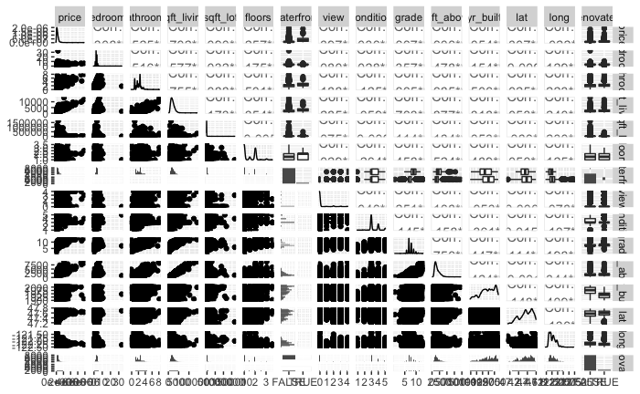

```r
ggpairs(house_trim)
```

Interested in:

price ~

sqft_living, sqft_above, bathrooms, waterfront, grade, view

## plot simple linear regression

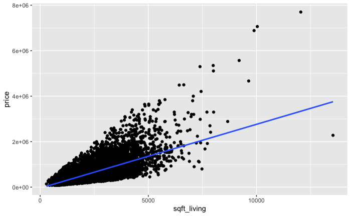

```r
house_trim_numeric %>%
  ggplot(aes(x = sqft_living, y = price)) +
  geom_point() +
  geom_smooth(method = "lm", se = FALSE)
```

## start model build

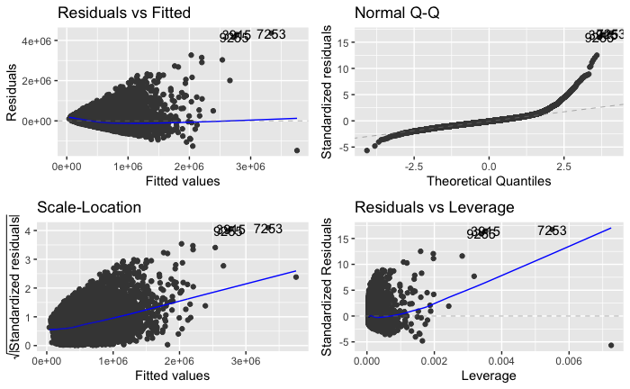

```r
model <- lm(price ~ sqft_living, data = house_trim_numeric)

autoplot(model)
```

```r
summary(model)
```

```
Call:
lm(formula = price ~ sqft_living, data = house_trim_numeric)

Residuals:
     Min       1Q   Median       3Q      Max
-1476062  -147486   -24043   106182  4362067

Coefficients:
              Estimate Std. Error t value Pr(>|t|)
(Intercept) -43580.743   4402.690  -9.899   <2e-16 ***
sqft_living    280.624      1.936 144.920   <2e-16 ***
---
Signif. codes:  0 ‘***’ 0.001 ‘**’ 0.01 ‘*’ 0.05 ‘.’ 0.1 ‘ ’ 1

Residual standard error: 261500 on 21611 degrees of freedom
Multiple R-squared:  0.4929,    Adjusted R-squared:  0.4928
F-statistic: 2.1e+04 on 1 and 21611 DF,  p-value: < 2.2e-16
```

r^2 = 0.4929 res = 261500

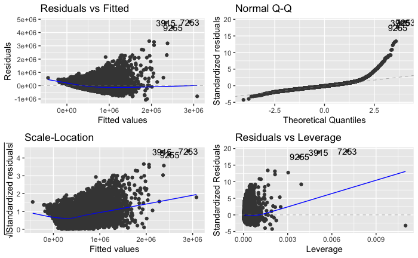

```r
model2 <- lm(price ~ sqft_living + grade, data = house_trim_numeric)

autoplot(model2)
```

```r
summary(model2)
```

```
Call:
lm(formula = price ~ sqft_living + grade, data = house_trim_numeric)

Residuals:
     Min       1Q   Median       3Q      Max
-1065457  -138304   -25043   100447  4794633

Coefficients:
              Estimate Std. Error t value Pr(>|t|)
(Intercept) -5.981e+05  1.330e+04  -44.98   <2e-16 ***
sqft_living  1.844e+02  2.869e+00   64.29   <2e-16 ***
grade        9.855e+04  2.241e+03   43.97   <2e-16 ***
---
Signif. codes:  0 ‘***’ 0.001 ‘**’ 0.01 ‘*’ 0.05 ‘.’ 0.1 ‘ ’ 1

Residual standard error: 250500 on 21610 degrees of freedom
Multiple R-squared:  0.5345,    Adjusted R-squared:  0.5345
F-statistic: 1.241e+04 on 2 and 21610 DF,  p-value: < 2.2e-16
```

r^2 = 0.5345 res = 250500

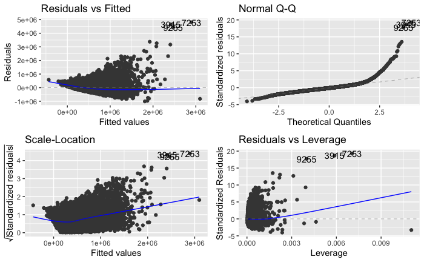

```r
model3 <- lm(price ~ sqft_living + grade + bathrooms, data = house_trim_numeric)

autoplot(model3)
```

```r
summary(model3)
```

```
Call:
lm(formula = price ~ sqft_living + grade + bathrooms, data = house_trim_numeric)

Residuals:
     Min       1Q   Median       3Q      Max
-1008780  -136352   -23106   100673  4801889

Coefficients:
              Estimate Std. Error t value Pr(>|t|)
(Intercept) -5.977e+05  1.326e+04  -45.07   <2e-16 ***
sqft_living  2.033e+02  3.331e+00   61.04   <2e-16 ***
grade        1.039e+05  2.286e+03   45.44   <2e-16 ***
bathrooms   -3.809e+04  3.440e+03  -11.07   <2e-16 ***
---
Signif. codes:  0 ‘***’ 0.001 ‘**’ 0.01 ‘*’ 0.05 ‘.’ 0.1 ‘ ’ 1

Residual standard error: 249800 on 21609 degrees of freedom
Multiple R-squared:  0.5371,    Adjusted R-squared:  0.5371
F-statistic:  8359 on 3 and 21609 DF,  p-value: < 2.2e-16
```

r^2 = 0.5371 res = 249800

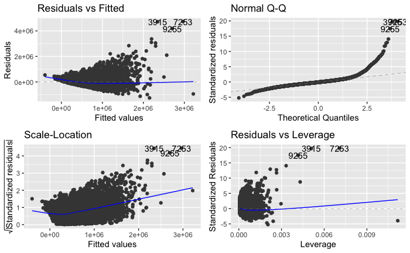

```r
model4 <- lm(price ~ sqft_living + grade + view, data = house_trim_numeric)

autoplot(model4)
```

```r
summary(model4)
```

```
Call:
lm(formula = price ~ sqft_living + grade + view, data = house_trim_numeric)

Residuals:
     Min       1Q   Median       3Q      Max
-1251382  -129449   -20575    97552  4732904

Coefficients:
              Estimate Std. Error t value Pr(>|t|)
(Intercept) -543450.45   12804.04  -42.44   <2e-16 ***
sqft_living     166.32       2.78   59.84   <2e-16 ***
grade         93344.46    2151.14   43.39   <2e-16 ***
view          97615.51    2226.10   43.85   <2e-16 ***
---
Signif. codes:  0 ‘***’ 0.001 ‘**’ 0.01 ‘*’ 0.05 ‘.’ 0.1 ‘ ’ 1

Residual standard error: 240000 on 21609 degrees of freedom
Multiple R-squared:  0.5725,    Adjusted R-squared:  0.5725
F-statistic:  9648 on 3 and 21609 DF,  p-value: < 2.2e-16
```

r^2 = 0.5725 res = 240000

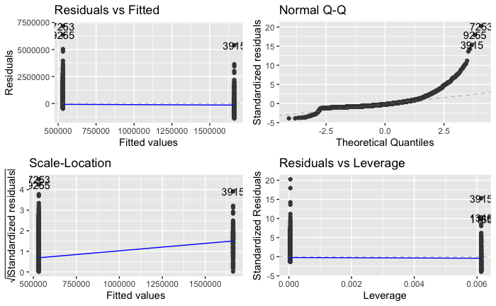

```r
model_nn_1 <- lm(price ~ waterfront, data = house_trim_nonnumeric)

autoplot(model_nn_1)
```

```r
summary(model_nn_1)
```

```
Call:
lm(formula = price ~ waterfront, data = house_trim_nonnumeric)

Residuals:
     Min       1Q   Median       3Q      Max
-1376876  -211564   -81564   108436  7168436

Coefficients:
               Estimate Std. Error t value Pr(>|t|)
(Intercept)      531564       2416  220.00   <2e-16 ***
waterfrontTRUE  1130312      27822   40.63   <2e-16 ***
---
Signif. codes:  0 ‘***’ 0.001 ‘**’ 0.01 ‘*’ 0.05 ‘.’ 0.1 ‘ ’ 1

Residual standard error: 353900 on 21611 degrees of freedom
Multiple R-squared:  0.07095,   Adjusted R-squared:  0.07091
F-statistic:  1650 on 1 and 21611 DF,  p-value: < 2.2e-16
```

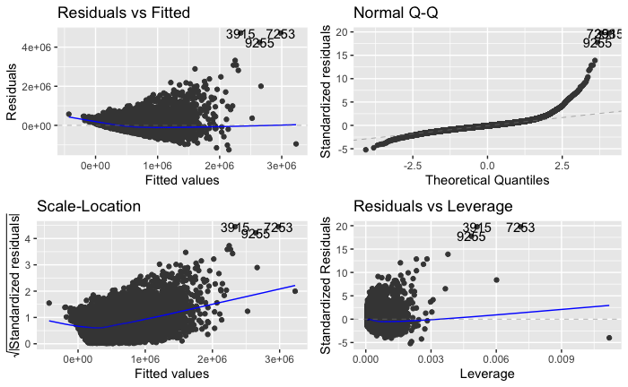

```r
model5 <- lm(price ~ sqft_living + grade + view + sqft_above, data = house_trim_numeric)

autoplot(model5)
```

```r
summary(model5)
```

```
Call:
lm(formula = price ~ sqft_living + grade + view + sqft_above,
    data = house_trim_numeric)

Residuals:
     Min       1Q   Median       3Q      Max
-1248638  -128196   -20339    96716  4725002

Coefficients:
              Estimate Std. Error t value Pr(>|t|)
(Intercept) -5.744e+05  1.318e+04 -43.587   <2e-16 ***
sqft_living  1.941e+02  4.011e+00  48.394   <2e-16 ***
grade        9.971e+04  2.247e+03  44.377   <2e-16 ***
view         9.324e+04  2.268e+03  41.113   <2e-16 ***
sqft_above  -4.172e+01  4.349e+00  -9.592   <2e-16 ***
---
Signif. codes:  0 ‘***’ 0.001 ‘**’ 0.01 ‘*’ 0.05 ‘.’ 0.1 ‘ ’ 1

Residual standard error: 239500 on 21608 degrees of freedom
Multiple R-squared:  0.5744,    Adjusted R-squared:  0.5743
F-statistic:  7289 on 4 and 21608 DF,  p-value: < 2.2e-16
```

r^2 = 0.5744 res = 239500

```r
anova(model5)
```

```
Analysis of Variance Table

Response: price
               Df     Sum Sq    Mean Sq  F value    Pr(>F)
sqft_living     1 1.4356e+15 1.4356e+15 25019.67 < 2.2e-16 ***
grade           1 1.2132e+14 1.2132e+14  2114.32 < 2.2e-16 ***
view            1 1.1080e+14 1.1080e+14  1930.96 < 2.2e-16 ***
sqft_above      1 5.2796e+12 5.2796e+12    92.01 < 2.2e-16 ***
Residuals   21608 1.2399e+15 5.7380e+10
---
Signif. codes:  0 ‘***’ 0.001 ‘**’ 0.01 ‘*’ 0.05 ‘.’ 0.1 ‘ ’ 1
```